# How to calculate the eFIBI using eDNA data

**Richard White**  
Quantitative Freshwater Ecologist  
03 September 2026

[figure not shown]

This document contains instructions to calculate the Fish Index of Biotic Integrity developed for use with eDNA data (the eFIBI) by White et al. (2026). R code required to calculate eFIBI is presented in grey boxes, with output shown in white boxes. Alternatively, the full R-code for this tutorial is present in the RMarkdown file (Calculate_eFIBI.Rmd) in this repository, which can be run in R. To follow these instructions you will need the files within the “Functions” “Models” and “Data” folders that accompany this document.

# 1 Load required packages

Calculating eFIBI with this script requires certain packages to be installed and loaded into the working environment.

```r
library(tidyverse)#Used for wrangling dataframes
library(brms)#Used to generate predictions of maximum species richness as a function of distance and elevation of the eDNA sample
library(here)#for detecting working directory
```

# 2 Load and inspect data

To calculate eFIBI with this script it is assumed you have your eDNA data prepared in a very specific format, an example of which is provided below:

```r
#load an example dataset
load(paste0(here(),"/Data/example.dataframe.RData"))
```

This loads an object called `edna.dat` which contains lists of fishes detected within each sample. For example, seven fishes were detected in the sample collected at `site.id` `1100306.77013553_4920207.01803971`, on date `2023-06-24`. Five were resolved to the `species` level and two were resolved to `genus` level. A sample consists of a composite of 6 eDNA sub-samples collected following methods described by Melchior and Baker (2023). A fish taxon is considered detected in a sample if at least five reads belonging to that taxon is detected in at least two of the sub-samples.

```r
edna.dat%>%
  filter(site.id=="1100306.77013553_4920207.01803971",
         date=="2023-06-24")
```

```
## # A tibble: 7 × 8
##   site.id                           date       elevation distance species_code
##   <chr>                             <date>         <dbl>    <dbl> <chr>
## 1 1100306.77013553_4920207.01803971 2023-06-24        14     1.26 angdie
## 2 1100306.77013553_4920207.01803971 2023-06-24        14     1.26 galaxi
## 3 1100306.77013553_4920207.01803971 2023-06-24        14     1.26 galarg
## 4 1100306.77013553_4920207.01803971 2023-06-24        14     1.26 galbre
## 5 1100306.77013553_4920207.01803971 2023-06-24        14     1.26 galfas
## 6 1100306.77013553_4920207.01803971 2023-06-24        14     1.26 gobiom
## 7 1100306.77013553_4920207.01803971 2023-06-24        14     1.26 gobhut
##   scientific.name        rank    genus
##   <chr>                  <chr>   <chr>
## 1 Anguilla dieffenbachii species Anguilla
## 2 Galaxias               genus   Galaxias
## 3 Galaxias argenteus     species Galaxias
## 4 Galaxias brevipinnis   species Galaxias
## 5 Galaxias fasciatus     species Galaxias
## 6 Gobiomorphus           genus   Gobiomorphus
## 7 Gobiomorphus huttoni   species Gobiomorphus
```

The data must contain the following columns with names and formats specified as shown:

- **site.id**: a unique character string designating the site name where the sample was taken. Can be any character string as long as it is unique to the site.
- **date**: the date on which the sample was taken.
- **elevation**: the elevation (meters above sea level) of the site.
- **distance**: the river-run distance from the site to the coast (km). Calculated from the midpoint of the nearest nzsegment on the Digital River Network v2.4.
- **species_code**: a 6-letter unique character code of the fish detected. This is a concatenation of the first 3 letters of the genus and species names shown in the scientific.name column. For example, `Anguilla dieffenbachii` is a concatenation of *ang* and *die*. One exception to this rule is for `Galaxias macronasus` which is coded as `galmar`, as it would otherwise share the same code used for `Galaxias maculatus` (i.e., `galmac`). If the fish has only been identified to the genus level, then the first 6 letters of the genus name is used. For example, `Galaxias` becomes `galaxi`.
- **scientific.name**: scientific name of the fish detected in the sample. Not necessary to calculate eFIBI, but provided here to give context.
- **rank**: the taxonomic resolution of `species_code`. Must be either `species`, `genus` or `NA`, if no fish were detected in a sample. Note, genus-level entries are eDNA detections that could not be resolved to a species. It is therefore possible to have an entry for an unresolved `genus`, and an additional entry for a `species` of that `genus` within the same sample.
- **genus**: the genus name of the detected fish.

Samples where no fish taxa were detected are retained in the dataset and encoded using `species_code == "nospec"`.

```r
head(edna.dat%>%filter(species_code=="nospec"))
```

```
## # A tibble: 6 × 8
##   site.id                           date       elevation distance species_code
##   <chr>                             <date>         <dbl>    <dbl> <chr>
## 1 1444923.20799336_5027414.91500942 2022-09-14        46    13.1  nospec
## 2 1463147.32766072_5247246.80529779 2024-01-31       781    56.3  nospec
## 3 1463164.32728533_5247213.26034815 2024-01-31       782    56.8  nospec
## 4 1465648.74290836_5250445.11749471 2024-01-31       577    52.0  nospec
## 5 1467350.67321159_5255471.79828449 2024-01-30       713    47.1  nospec
## 6 1501919.34481057_5121202.22237322 2022-08-22        22     3.04 nospec
##   scientific.name     rank  genus
##   <chr>               <chr> <chr>
## 1 No species detected <NA>  <NA>
## 2 No species detected <NA>  <NA>
## 3 No species detected <NA>  <NA>
## 4 No species detected <NA>  <NA>
## 5 No species detected <NA>  <NA>
## 6 No species detected <NA>  <NA>
```

Each species_code must be unique within each sample, which is the case with these data:

```r
edna.dat%>%
  group_by(site.id,date)%>%
  mutate(duplicated.taxon=duplicated(species_code))%>%
  filter(duplicated.taxon==TRUE)
```

```
## # A tibble: 0 × 9
## # Groups:   site.id, date [0]
## # ℹ 9 variables: site.id <chr>, date <date>, elevation <dbl>, distance <dbl>, species_code <chr>, scientific.name <chr>, rank <chr>, genus <chr>, duplicated.taxon <lgl>
```

# 3 Load and inspect eFIBI sub-metric taxonomic key

An eFIBI score of a sample is the summation of six sub-metrics:

1. total native richness
2. native richness of riffle-dwelling species
3. native richness of benthic pool species
4. native richness of pelagic pool species
5. richness of native intolerant species
6. proportion of species at a site that are native

To compute richness within each sub-metric we need a key to identify which sub-metric each fish taxon belongs to. The key loaded and displayed below shows how each `species_code` in the data contribute to richness of each sub-metric:

```r
load(paste0(here(),"/Data/submetric_species.RData"))

head(submetric_species)
```

```
## # A tibble: 6 × 7
##   species_code native benthic_riffle benthic_pool pelagic_pool intolerant
##   <chr>         <dbl>          <dbl>        <dbl>        <dbl>      <dbl>
## 1 aldfor            1              0            0            1          0
## 2 aldric            1              0            0            1          0
## 3 ameiur            0              0            0            0          0
## 4 ameneb            0              0            0            0          0
## 5 angaus            1              0            1            0          0
## 6 angdie            1              1            1            0          0
##   non_native
##        <dbl>
## 1          0
## 2          0
## 3          1
## 4          1
## 5          0
## 6          0
```

# 4 Load and inspect maximum species richness models

The score for each eFIBI sub-metric is calculated by comparing the richness observed in the sample to the *maximum richness* predicted if anthropogenic impacts on the river were minimal. Predictions of *maximum richness* within each sample are made using the models loaded below:

```r
load(paste0(here(),"/Models/richness.models.RData"))
```

The loaded object, `richness.models`, is a `list()` containing five Bayesian Generalised Linear Models (BGLMs). These BGLMs predict richness for the first five sub-metrics as a function of `distance` and `elevation` of the sample site. For example, the model to predict expected richness of the native species sub-metric is:

```r
richness.models$Native
```

```
##  Family: negbinomial
##   Links: mu = log
## Formula: native ~ 0 + Intercept + distance + elevation
##    Data: nat.edna.ibi.e (Number of observations: 1407)
##   Draws: 4 chains, each with iter = 6000; warmup = 3000; thin = 1;
##          total post-warmup draws = 12000
##
## Regression Coefficients:
##           Estimate Est.Error l-95% CI u-95% CI Rhat Bulk_ESS Tail_ESS
## Intercept     1.78      0.02     1.75     1.82 1.00     4245     4056
## distance     -0.00      0.00    -0.00    -0.00 1.00    10189     7211
## elevation    -0.00      0.00    -0.00    -0.00 1.00     9332     7939
##
## Further Distributional Parameters:
##       Estimate Est.Error l-95% CI u-95% CI Rhat Bulk_ESS Tail_ESS
## shape    13.56      1.79    10.45    17.45 1.00     4011     4266
##
## Draws were sampled using sampling(NUTS). For each parameter, Bulk_ESS
## and Tail_ESS are effective sample size measures, and Rhat is the potential
## scale reduction factor on split chains (at convergence, Rhat = 1).
```

# 5 Calculate eFIBI for sample data

A function is provided that uses the sample data, maximum richness models, and sub-metric key, to calculate eFIBI for each sample. The function is provided as a separate R script in `./Functions/calculate.efibi.R`, as well in Appendix 1. To load the script into R:

```r
source(paste0(here(),"./Functions/calculate.efibi.R"))
```

To use the function, simply provide it with your sample data,`edna.dat`, the `richness.models` and the submetric key `submetric_species`. Setting the seed is optional (default seed=1) but necessary to ensure reproducibility given that maximum species richness estimates are drawn from the model posterior predictive distribution, and can therefore vary slightly each time the function is run.

```r
results<-calculate.efibi(Data=edna.dat,models=richness.models,key=submetric_species,seed=1)
```

```
## Calculating observed sub-metric richness
```

```
## Estimating maximum richness
```

```
## Calculating eFIBI
```

The `results` contains, for each sample:

- The observed richness of taxa belonging to each sub-metric (`native`, `benthic_riffle`, `benthic_pool`, `pelagic_pool`, `intolerant`, `non-native`), and the proportion of taxa that were native (`p.native`)
- Scores for each sub-metric (`xxxx_score`)
- The final `eFIBI` score, which is a summation of the sub-metric scores.

```r
head(results)
```

```
## # A tibble: 6 × 18
##   site.id                           date       elevation distance native
##   <chr>                             <date>         <dbl>    <dbl>  <dbl>
## 1 1100306.77013553_4920207.01803971 2023-06-24        14    1.26       5
## 2 1105691.12048488_4918829.90683182 2023-06-27        19    0.712      7
## 3 1106582.85193649_4929748.96554162 2023-06-28        16    0.158      8
## 4 1110740.12512285_4921277.20314005 2023-06-28        14    0.252      6
## 5 1142297.36571593_4862495.77113273 2023-03-13        12    0.475     10
## 6 1144201.3629665_4862051.76936939  2023-03-14        41    2.06       4
##   benthic_riffle benthic_pool pelagic_pool intolerant non_native p.native
##            <dbl>        <dbl>        <dbl>      <dbl>      <dbl>    <dbl>
## 1              3            3            2          4          0    1
## 2              3            5            2          4          0    1
## 3              3            4            4          4          0    1
## 4              3            3            3          4          0    1
```

[output cut: 18 more lines]

Plot results:

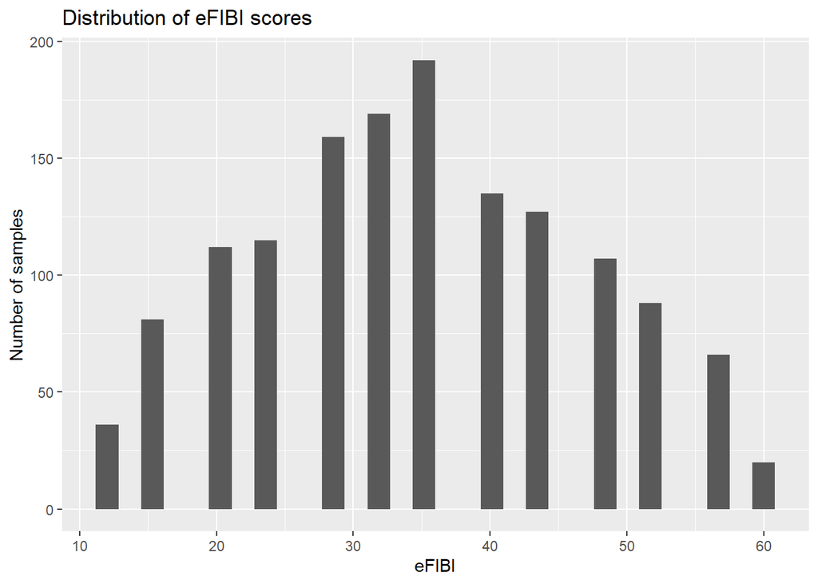

```r
results%>%
  ggplot(aes(x=eFIBI))+
  geom_histogram()+
  labs(
    title = "Distribution of eFIBI scores",
    x = "eFIBI",
    y = "Number of samples"
  )
```